# Exploratory Data Analysis of Prosper Loan Data

# Abstract

Prosper is a peer-to-peer lending platform that aims to connect people who need money with those who have money to invest. In this Exploratory Data Analysis, I explore a Prosper dataset containing loan information for over a 100,000 people between the years 2006 and 2013. The data is provided by Udacity as a part of Explore and Summarize Data. This data set contains 113,937 loans with 81 variables on each loan, including loan amount, borrower rate (or interest rate), current loan status, borrower income, borrower employment status, borrower credit history, and the latest payment information. The exploration is divided into 3 analytical segments in increasing order of complexity: Univariate Plots, Bivariate Plots, and Multivariate Plots, as well as a Reflection segment at the end that summarizes my experience and thoughts throughout this EDA.

# Univariate Plots Section

Let’s take a look at the size of this dataset and the datatypes of its variables:

```
## [1] 113937     81
```

```
## 'data.frame':    113937 obs. of  81 variables:
##  $ ListingKey                         : Factor w/ 113066 levels "00003546482094282EF90E5",..: 7180 7193 6647 6669 6686 6689 6699 6706 6687 6687 ...
##  $ ListingNumber                      : int  193129 1209647 81716 658116 909464 1074836 750899 768193 1023355 1023355 ...
##  $ ListingCreationDate                : Factor w/ 113064 levels "2005-11-09 20:44:28.847000000",..: 14184 111894 6429 64760 85967 100310 72556 74019 97834 97834 ...
##  $ CreditGrade                        : Factor w/ 9 levels "","A","AA","B",..: 5 1 8 1 1 1 1 1 1 1 ...
##  $ Term                               : int  36 36 36 36 36 60 36 36 36 36 ...
##  $ LoanStatus                         : Factor w/ 12 levels "Cancelled","Chargedoff",..: 3 4 3 4 4 4 4 4 4 4 ...
##  $ ClosedDate                         : Factor w/ 2803 levels "","2005-11-25 00:00:00",..: 1138 1 1263 1 1 1 1 1 1 1 ...
##  $ BorrowerAPR                        : num  0.165 0.12 0.283 0.125 0.246 ...
##  $ BorrowerRate                       : num  0.158 0.092 0.275 0.0974 0.2085 ...
##  $ LenderYield                        : num  0.138 0.082 0.24 0.0874 0.1985 ...
##  $ EstimatedEffectiveYield            : num  NA 0.0796 NA 0.0849 0.1832 ...
##  $ EstimatedLoss                      : num  NA 0.0249 NA 0.0249 0.0925 ...
##  $ EstimatedReturn                    : num  NA 0.0547 NA 0.06 0.0907 ...
##  $ ProsperRating..numeric.            : int  NA 6 NA 6 3 5 2 4 7 7 ...
```

[output cut: 67 more lines]

```
##                    ListingKey     ListingNumber
##  17A93590655669644DB4C06:     6   Min.   :      4
##  349D3587495831350F0F648:     4   1st Qu.: 400919
##  47C1359638497431975670B:     4   Median : 600554
##  8474358854651984137201C:     4   Mean   : 627886
##  DE8535960513435199406CE:     4   3rd Qu.: 892634
##  04C13599434217079754AEE:     3   Max.   :1255725
##  (Other)                :113912
##                     ListingCreationDate  CreditGrade         Term
##  2013-10-02 17:20:16.550000000:     6          :84984   Min.   :12.00
##  2013-08-28 20:31:41.107000000:     4   C      : 5649   1st Qu.:36.00
##  2013-09-08 09:27:44.853000000:     4   D      : 5153   Median :36.00
##  2013-12-06 05:43:13.830000000:     4   B      : 4389   Mean   :40.83
##  2013-12-06 11:44:58.283000000:     4   AA     : 3509   3rd Qu.:36.00
##  2013-08-21 07:25:22.360000000:     3   HR     : 3508   Max.   :60.00
##  (Other)                      :113912   (Other): 6745
##                  LoanStatus                  ClosedDate
##  Current              :56576                      :58848
##  Completed            :38074   2014-03-04 00:00:00:  105
##  Chargedoff           :11992   2014-02-19 00:00:00:  100
##  Defaulted            : 5018   2014-02-11 00:00:00:   92
##  Past Due (1-15 days) :  806   2012-10-30 00:00:00:   81
##  Past Due (31-60 days):  363   2013-02-26 00:00:00:   78
##  (Other)              : 1108   (Other)            :54633
##   BorrowerAPR       BorrowerRate     LenderYield
##  Min.   :0.00653   Min.   :0.0000   Min.   :-0.0100
##  1st Qu.:0.15629   1st Qu.:0.1340   1st Qu.: 0.1242
##  Median :0.20976   Median :0.1840   Median : 0.1730
##  Mean   :0.21883   Mean   :0.1928   Mean   : 0.1827
##  3rd Qu.:0.28381   3rd Qu.:0.2500   3rd Qu.: 0.2400
##  Max.   :0.51229   Max.   :0.4975   Max.   : 0.4925
##  NA's   :25
##  EstimatedEffectiveYield EstimatedLoss   EstimatedReturn
##  Min.   :-0.183          Min.   :0.005   Min.   :-0.183
##  1st Qu.: 0.116          1st Qu.:0.042   1st Qu.: 0.074
##  Median : 0.162          Median :0.072   Median : 0.092
##  Mean   : 0.169          Mean   :0.080   Mean   : 0.096
##  3rd Qu.: 0.224          3rd Qu.:0.112   3rd Qu.: 0.117
##  Max.   : 0.320          Max.   :0.366   Max.   : 0.284
##  NA's   :29084           NA's   :29084   NA's   :29084
```

[output cut: 193 more lines]

```
##  Min.   :    0.00                Min.   :0.7000   Min.   : 0.00000
##  1st Qu.:    0.00                1st Qu.:1.0000   1st Qu.: 0.00000
##  Median :    0.00                Median :1.0000   Median : 0.00000
##  Mean   :   25.14                Mean   :0.9986   Mean   : 0.04803
##  3rd Qu.:    0.00                3rd Qu.:1.0000   3rd Qu.: 0.00000
##  Max.   :21117.90                Max.   :1.0125   Max.   :39.00000
##
##  InvestmentFromFriendsCount InvestmentFromFriendsAmount   Investors
##  Min.   : 0.00000           Min.   :    0.00            Min.   :   1.00
##  1st Qu.: 0.00000           1st Qu.:    0.00            1st Qu.:   2.00
##  Median : 0.00000           Median :    0.00            Median :  44.00
##  Mean   : 0.02346           Mean   :   16.55            Mean   :  80.48
##  3rd Qu.: 0.00000           3rd Qu.:    0.00            3rd Qu.: 115.00
##  Max.   :33.00000           Max.   :25000.00            Max.   :1189.00
##
```

Let’s quickly plot some simple histograms to study various variables :-

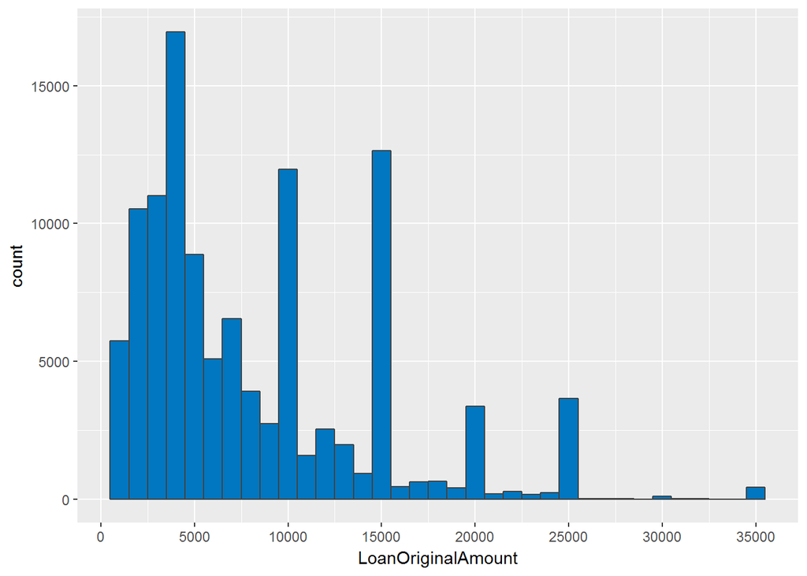

We can now explore IncomeRange as shown below.

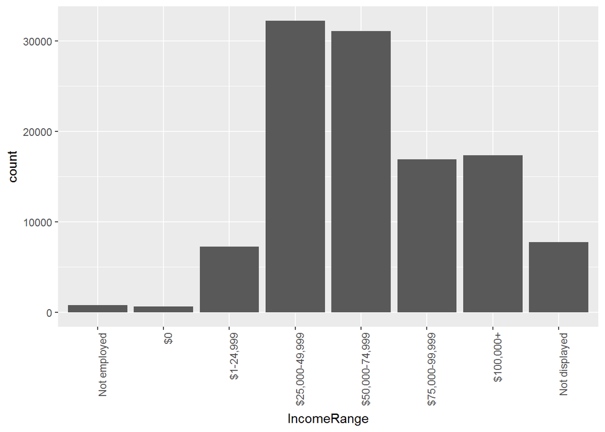

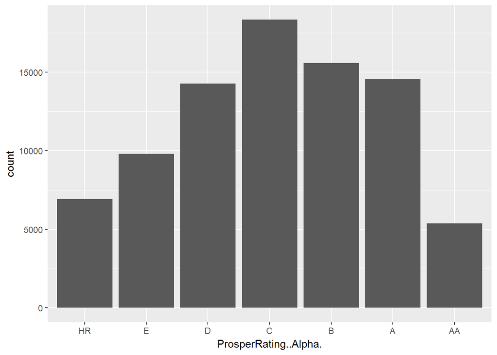

This plot shows that more people belong to the high risk categories of HR, E, D, C and B. Also roughly around 20,000 people belong to low risk categories of A and AA.

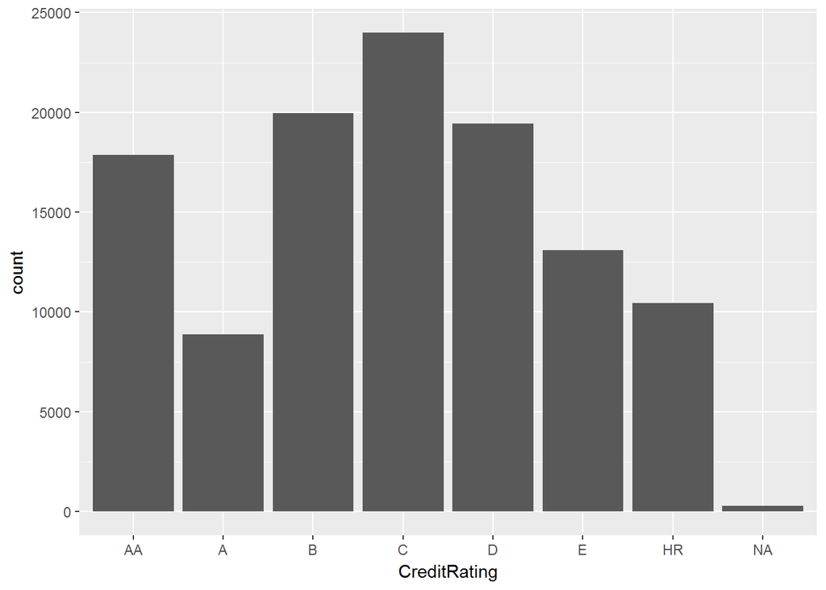

This plot is similar to the one plotted for Prosper rating above. Only difference is that the lowest risk category AA has higher count here than that in Prosper rating plot. This means that credit rating and prosper rating are almost similar kinds of ratings given by Prosper to its borrowers.

Let’s now analyse some background details of the borrower.

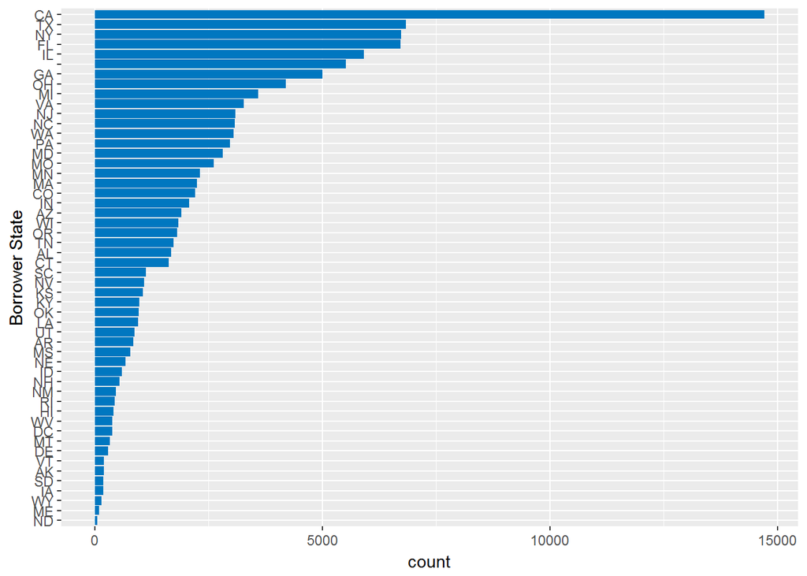

The popular states include California, Florida, New York, Texas and Illinois. Highest number of borrowers are from California perhaps because it is the state where Prosper was founded.

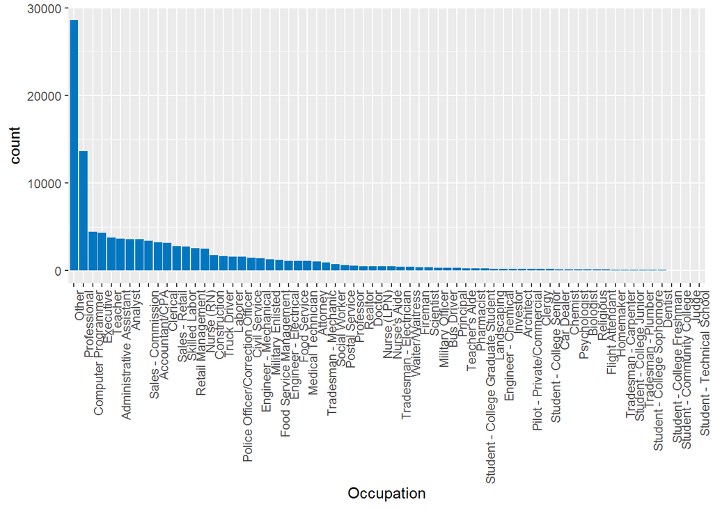

Interestingly the unclear occupations like other and Professional have higher count of borrowers. This may be because the borrowers didn’t want to reveal much about their occupation and instead choose these unclear occupations. . Among the rest of them, relatively popular ones include analysts, accountants, computer programmers, teachers and executives. Prosper has definitely enabled a wide range of working people to either borrow or invest money.

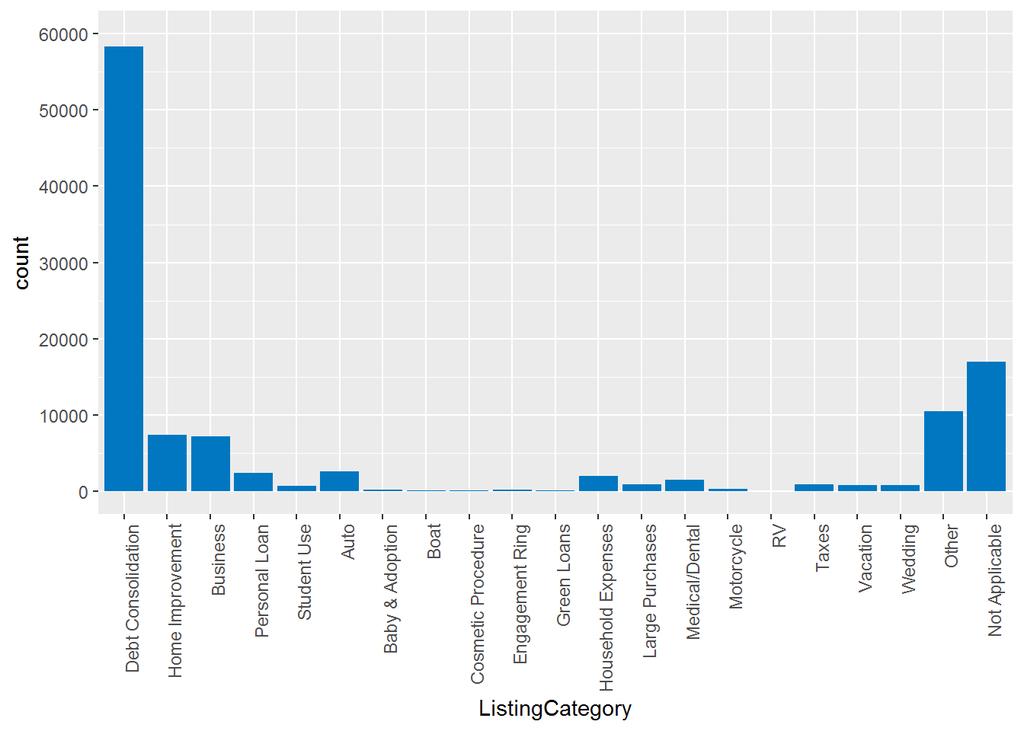

Most popular reasons to take a loan are Debt Consolidation, Home Improvement, Buisiness and Personal loan among several other reasons. These reasons seem to be valid and most obvious reasons for taking a loan.

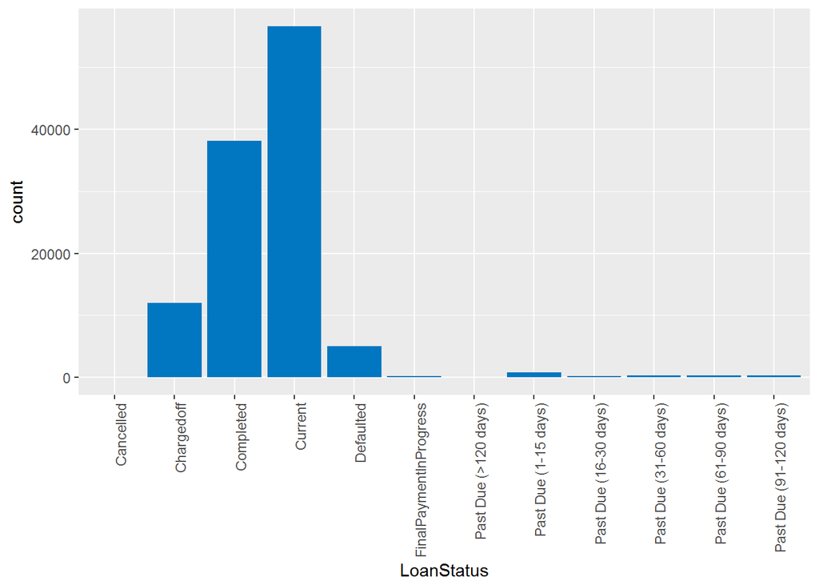

Most loans seem to still be ongoing, which is indicative of their booming growth.

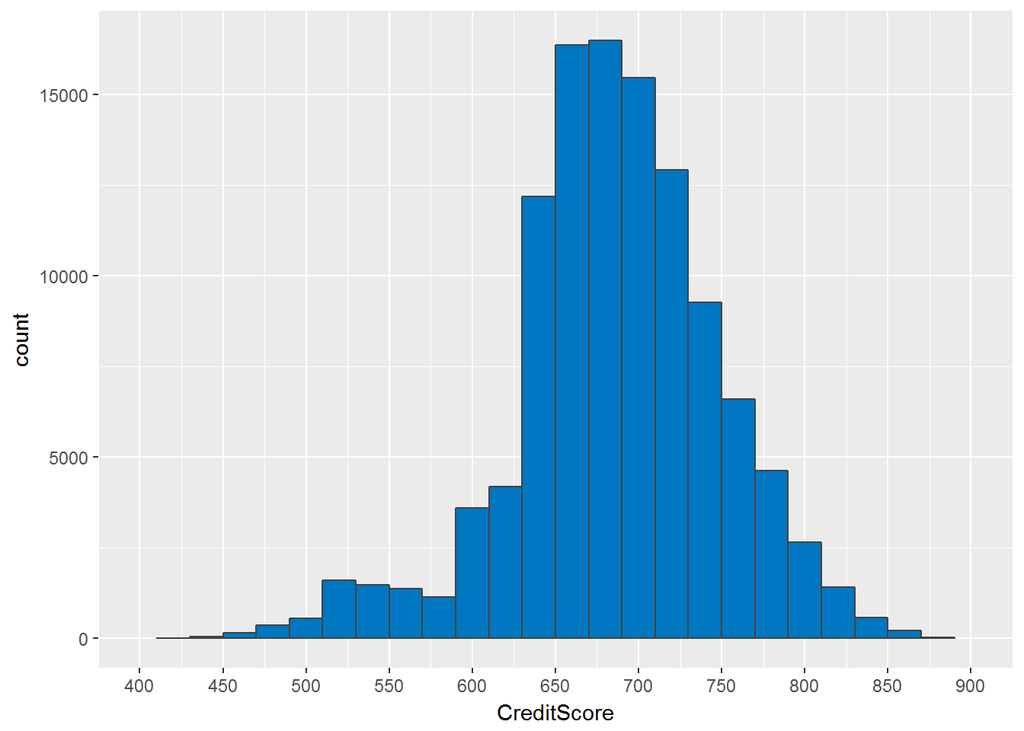

The plot clearly shows that a majority of the users lie between the 650 and 750 mark, which are decent credit scores and consistent with the previous plots, especially the loan amounts received.

Let’s now look at the interest rates on loan amounts. There are 3 variables showing the interest rates namely BorrowerAPR, BorrowerRate and LenderYield. The BorrowerAPR is the Borrower’s Annual Percentage Rate (APR) for the loan but the BorrowerRate is the interest rate for each month. The LenderYield is how much you actually profited from the investment, which is obtained by converting BorrowerRate into actual money in dollars.

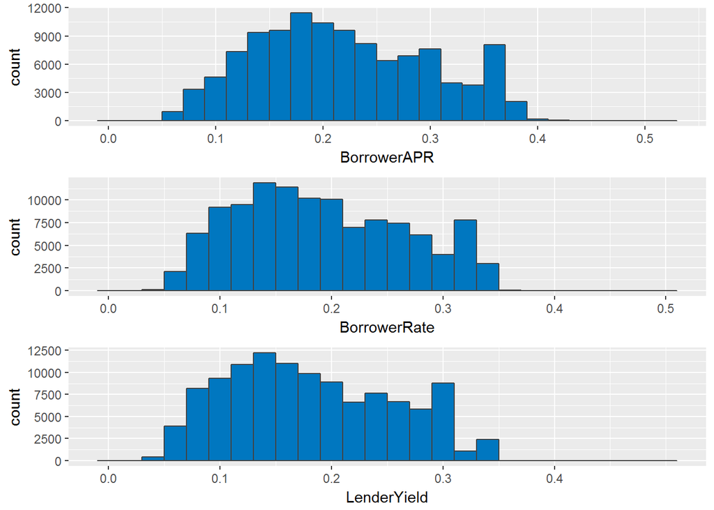

# Univariate Analysis

### What is the structure of your dataset?

**Categorical Variables** BorrowerState, Occupation, EmployementStatus, IsBorrowerHomeowner, IncomeRange, CreditGrade, LoanStatus and ListingCategory are the categorical variables analysed here.

**Numerical Variables** Term, BorrowerAPR, BorrowerRate, LenderYield, LoanOriginalAmount, EmploymentStatusDuration, StatedMonthlyIncome, DebtToIncomeRatio and ProsperScore are the main numerical variables analysed here.

### What is/are the main feature(s) of interest in your dataset?

The dataset seems to contain 81 variables. Since it is tedious to explore all 81 variables, i have spotted 20 important variables whose exploration is very necessary. Then i divided these 20 variables into 3 groups, just to make analysis easy :-

1. **Loan-Related variables :** This contains variables Term, LoanOriginalAmount,BorrowerAPR, BorrowerRate, LenderYield, LoanStatus and ListingCategory.
2. **Background details of borrower :** This contains variables which help us to analyse the economic state of borrowers like IncomeRange, StatedMonthlyIncome, EmploymentStatus, EmploymentStatusDuration, IsBorrowerHomeOwner, BorrowerState and Occupation.
3. **Risk variables :** This involves variables like CreditGrade, ProsperRating and ProsperScore which help us analyse which risk category the borrower belongs to.

### Of the features you investigated, were there any unusual distributions? Did you perform any operations on the data to tidy, adjust, or change the form of the data? If so, why did you do this?

The CreditScore when plotted had outlier at zero and so i had to set limits on x-axis( which is c(400, 900)) to get the correct plot.Other than this no other changes were done as the plots had nearly normal kind of distribution.

# Bivariate Plots Section

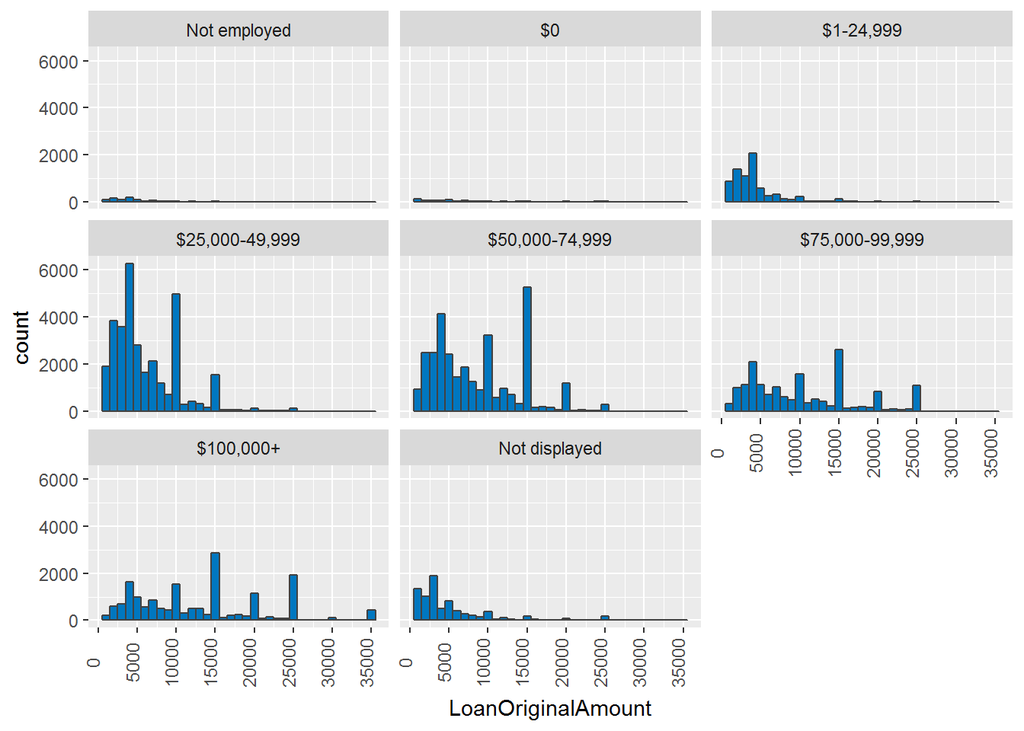

The people of extremely low income categories like Not employed, $0 and $1-24,999 are the ones who really need a loan. But the plot above shows that people of middle income range ($25,000 to $100,000) take larger loans. This may be due to basic salary requirements of the organization to grant a loan, which the low income range don’t meet easily and hence might be unable to get a loan.

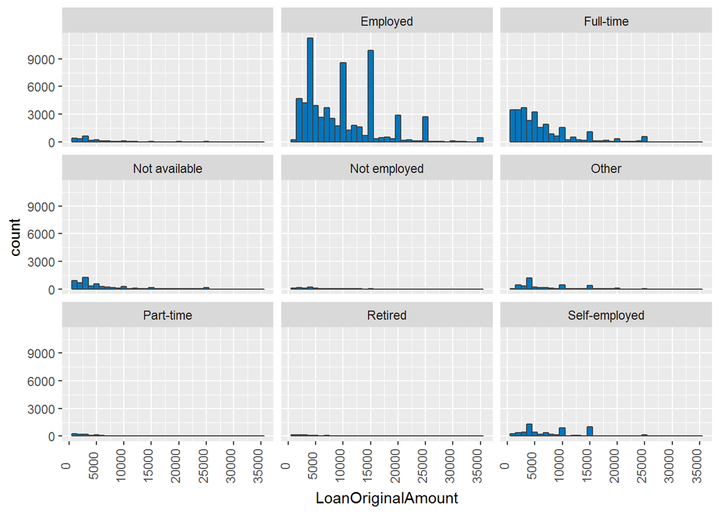

This plot is again evident of above observation that people belonging to employed categories like Employed, Full-time and Self-employed, take larger loan amounts.

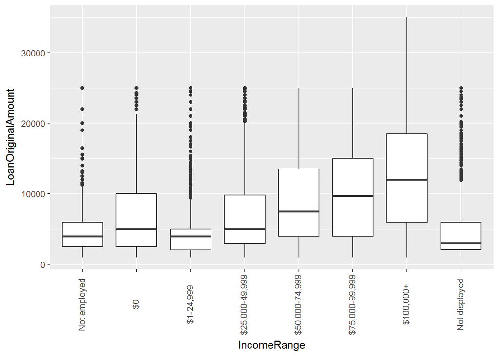

As the IncomeRange increases, the borrowed median LoanOriginalAmount also increased.

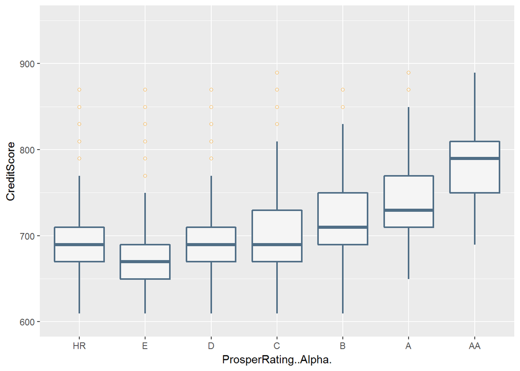

A person’s credit score is one of the key factors in determining their Prosper Rating, so it’s no surprise that as we climb the rating categories, the credit score of the borrowers also tend to increase.I see that ‘HR’ has a slightly higher median and IQR than ‘E’ despite being a riskier category - in fact, it’s on par with borrowers with a ‘D’ rating. Let’s take a quick look at their summaries to check the details:

```
## pl_data$ProsperRating..Alpha.:
##    Min. 1st Qu.  Median    Mean 3rd Qu.    Max.    NA's
##     9.5   609.5   649.5   653.9   709.5   889.5     591
## --------------------------------------------------------
## pl_data$ProsperRating..Alpha.: A
##    Min. 1st Qu.  Median    Mean 3rd Qu.    Max.
##   649.5   709.5   729.5   739.4   769.5   889.5
## --------------------------------------------------------
## pl_data$ProsperRating..Alpha.: AA
##    Min. 1st Qu.  Median    Mean 3rd Qu.    Max.
##   689.5   749.5   789.5   783.6   809.5   889.5
## --------------------------------------------------------
## pl_data$ProsperRating..Alpha.: B
##    Min. 1st Qu.  Median    Mean 3rd Qu.    Max.
##   609.5   689.5   709.5   716.4   749.5   869.5
## --------------------------------------------------------
## pl_data$ProsperRating..Alpha.: C
##    Min. 1st Qu.  Median    Mean 3rd Qu.    Max.
##   609.5   669.5   689.5   699.4   729.5   889.5
## --------------------------------------------------------
## pl_data$ProsperRating..Alpha.: D
##    Min. 1st Qu.  Median    Mean 3rd Qu.    Max.
##   609.5   669.5   689.5   689.8   709.5   869.5
## --------------------------------------------------------
## pl_data$ProsperRating..Alpha.: E
##    Min. 1st Qu.  Median    Mean 3rd Qu.    Max.
##   609.5   649.5   669.5   672.0   689.5   869.5
## --------------------------------------------------------
## pl_data$ProsperRating..Alpha.: HR
##    Min. 1st Qu.  Median    Mean 3rd Qu.    Max.
##   609.5   669.5   689.5   686.5   709.5   869.5
```

Now we can see that the medians of ‘HR’ and ‘D’ are the same, and the mean differs by just 3.3 to ‘D’. The median of ‘E’, on the other hand, is sandwiched between these two categories with a credit score median of 20 below.

Credit Score is one of the factors of Prosper’s rating categories, and these categories, along with some other financial information, determine the Annual Percentage Rate that a will apply to the borrower’s loan. So let’s see how the APR changes as the categories get less risky:

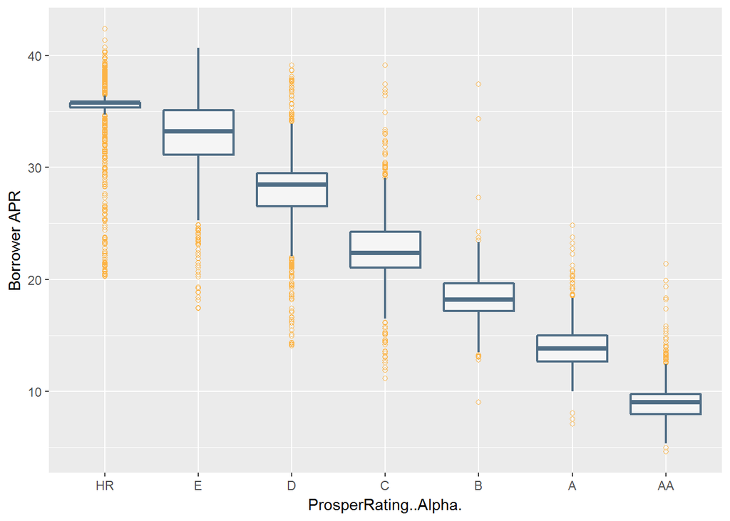

Let’s see how Prosper rating affects the LoanOriginalAmount :-

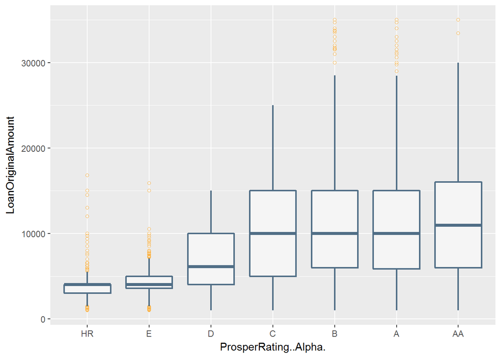

As expected, the groups of higher risk took lower loan amount and the groups C, B and A had the same median loan amounts. The lowest risk group AA shows highest median loan amount.

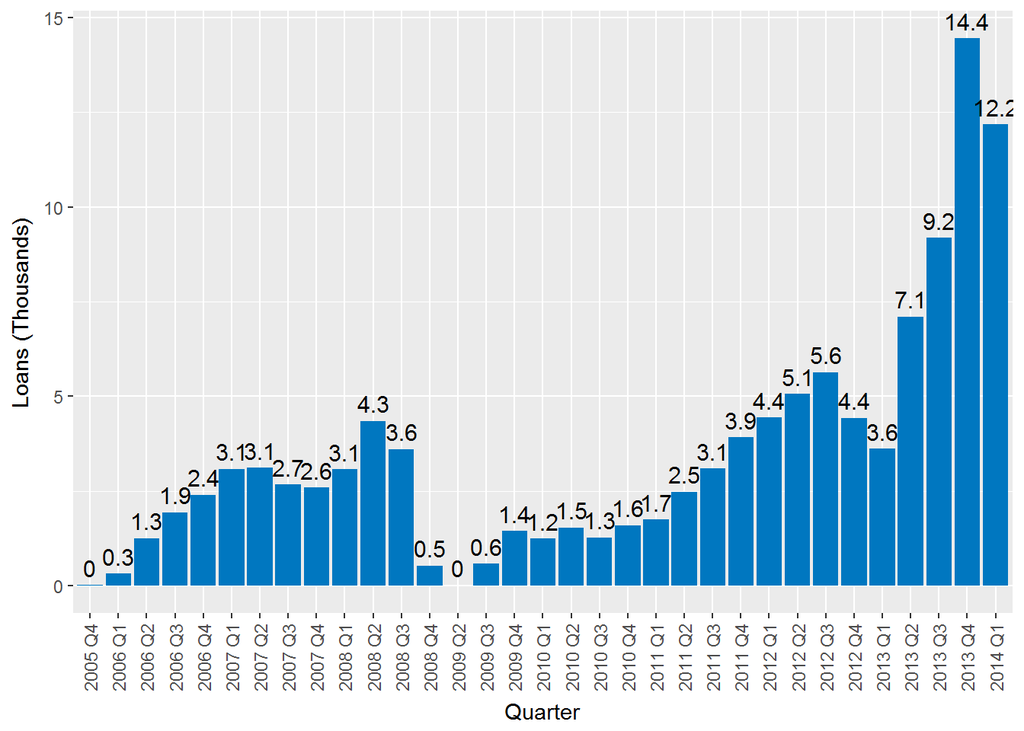

We can see the steady growth in number of loans from around 300 in 2006 Q1 to about 3100 two years later (2008 Q1) - a tenfold increase! But there’s a huge slump in the end of 2008, and which continues for the next 3 quarters (there’s no data for 2009 Q1). Post 2009, we can see the dramatic rise in the number of loans that were brokered, when Prosper went from around 1200 in the beginning of 2010 to 14,400 in just a mere 4 years. They were plagued by a lot of defaults in their early years, however, leading to lowering investor confidence, so it will be interesting to see if these changes have improved the success rate of loan completions in their marketplace. We’ll explore this over the course of this EDA (and some other stuff).

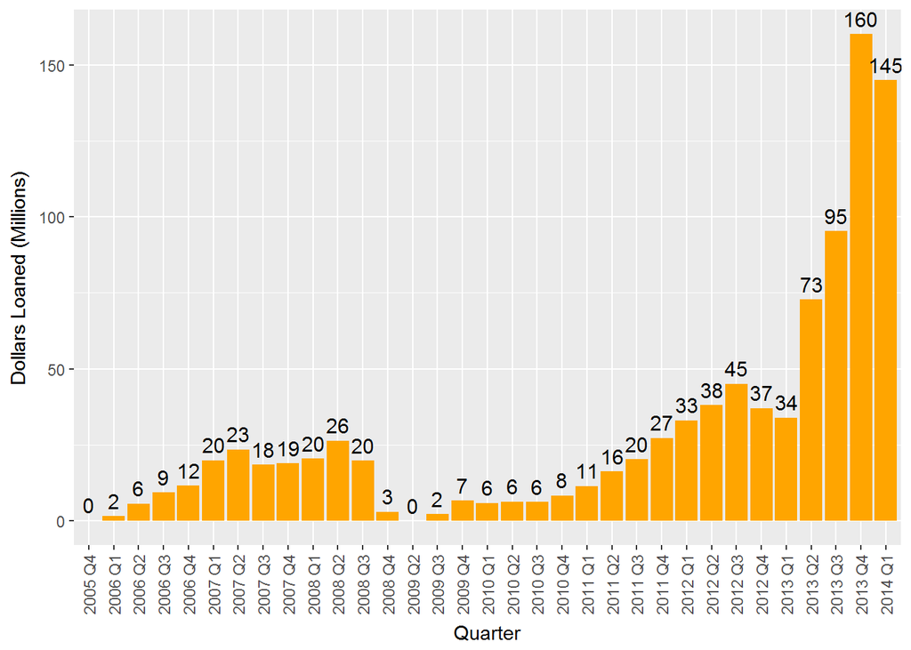

This plot is the same as the previous one, but with Dollar amounts instead of number of loans. Now both plots clearly show the increasing quantity of loans (and amount loaned) being organized by Prosper, which is an indicator of a growing business.

Finally let’s look at how the loans are being defaulted.

```
##              Cancelled             Chargedoff              Completed
##                      5                  11992                  38074
##                Current              Defaulted FinalPaymentInProgress
##                  56576                   5018                    205
##   Past Due (>120 days)   Past Due (1-15 days)  Past Due (16-30 days)
##                     16                    806                    265
##  Past Due (31-60 days)  Past Due (61-90 days) Past Due (91-120 days)
##                    363                    313                    304
```

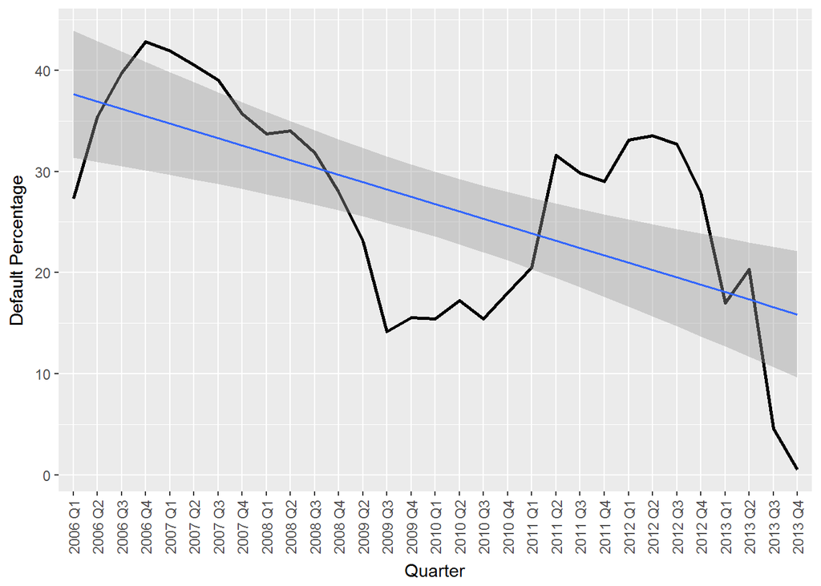

# Bivariate Analysis

### Talk about some of the relationships you observed in this part of the investigation. How did the feature(s) of interest vary with other features in the dataset?

The main variables of interest are LoanOriginalAmount, BorrowerAPR, Prosper rating, LoanOriginationQuarter and LoanStatus. The plots shown above reveal following relationships between these variables :-

1. The people of middle income range ($25,000 to $100,000) take larger loans than the income less groups.
2. The people belonging to employed categories like Employed, Full-time and Self-employed, take larger loan amounts compared to unemployed categories.
3. As the IncomeRange increases, the borrowed median LoanOriginalAmount also increased.
4. The groups of higher risk took lower loan amount i.e LoanOriginalAmount and the groups C, B and A had the same median loan amounts. The lowest risk group AA shows highest median loan amount.
5. The quantity of loans granted (LoanOriginalAmount) increases with LoanOriginationQuarter and this shows good growth of Prosper in lending loans.

### Did you observe any interesting relationships between the other features (not the main feature(s) of interest)?

# Multivariate Plots Section

Let’s now plot a scatterplot matrix to see relationships betwwen multiple variables at once. I’am first going to subset the dataset by taking only few variables and exclude the categorical variables.

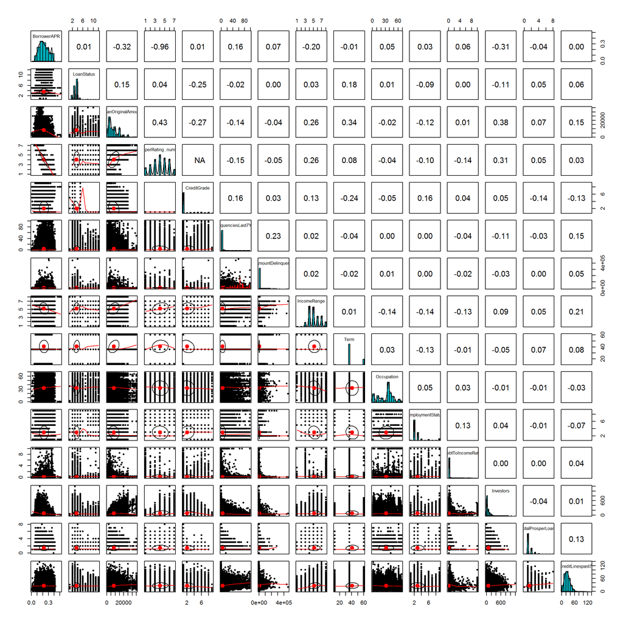

When analyzing loan services, we must also look at the quality of the loans. Increase in growth of loan originations is not constructive if most of the loans are being defaulted or charged off. So that’s what I’m going to create in the next plot: loan originations coloured by the status of the loan.

I see that there are 6 ‘Past Due’ factors based on how late the borrowers are with their payments, but it will be much more useful visually if they’re grouped as one.

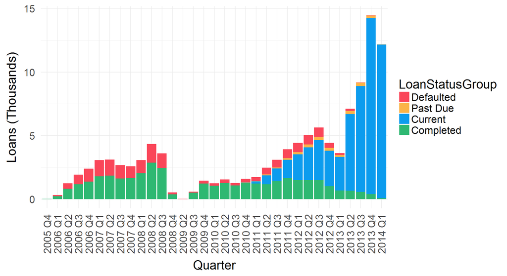

Now this plot provides us a lot of information. Not only do we see the growth of the company through it’s increasing loan openings, but we can also see the performance of loans over time. I’ve specifically chosen the colours for the plot - the red to yellow to green denote a progression from worse to better, and the light blue represents ongoing loans that will either end up being completed or defaulted in the future.

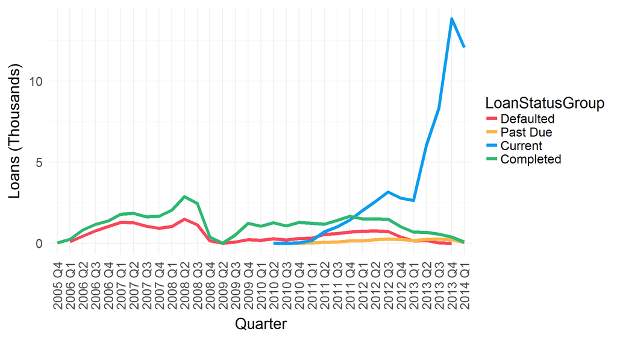

This plot shows the same time series data from the plot above, but with a line instead of a stacked bar chart.

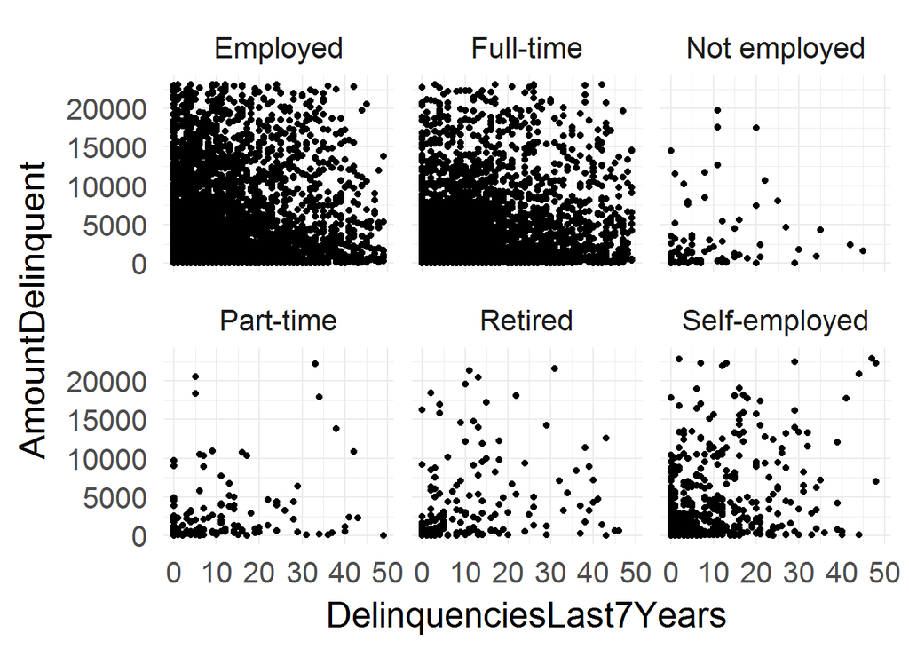

This plot doesn’t reveal much. I wanted to see the relationship between the amount borrowers were delinquent and the number of delinquencies they’ve had over the last 7 years. I then separated that by employment status to see if people that weren’t full employed had higher delinquencies or owed more money. The overplotting and general dispersion of data doesn’t really reveal the trend I hypothesized.

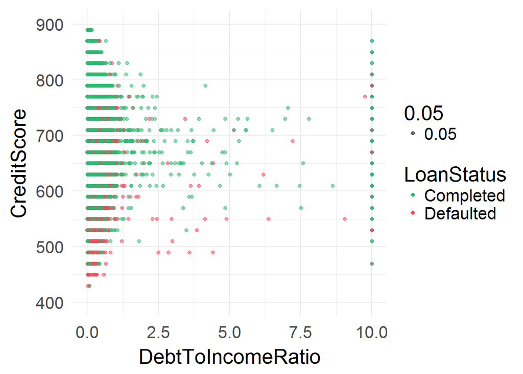

In this scatter plot, I notice that there is a lot of overplotting at the low end of the debt to income ratio, and a disctint line of points at a ratio of 10, with a sparse no-man’s land in between. The plot isn’t very informational. I notice that the defaulters tend to have lower credit scores - around 600 and below - displayed by the sea of red. Past 600 it seems mostly green, but once again it’s awfully overplotted and since I don’t see any other trends, I won’t take this any further.

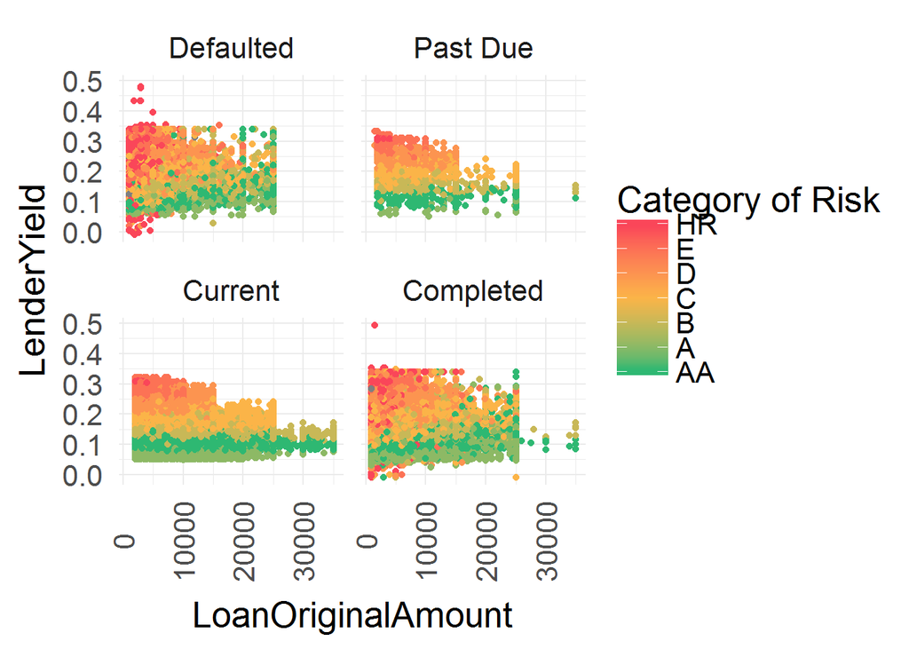

This plot shows the relationship between a lender yield on the loan and the amount that a borrower has loaned. I then made individual graphs to show that relationsip based on the status of the loan - Defaulted, Past Due, Current and Completed - and finally coloured it based on risk rating.

# Multivariate Analysis

### Were there any interesting or surprising interactions between features?

There were no such interesting interactions found between the variables in the analysis carried out here.

# Final Plots and Summary

### Plot One

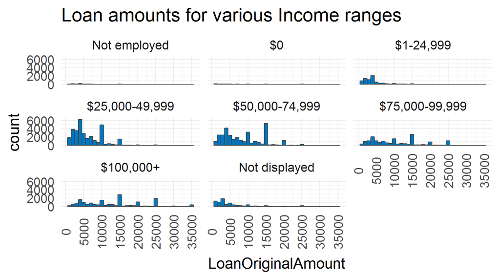

### Description One

IncomeRange is always an important parameter to judge whether a person is good at repaying the loans back. Faceting the above plot of loan amount using IncomeRange reveals a useful observation that people of middle income range ($25,000 to $100,000) take larger loans.But people of extremely low income categories like Not employed, $0 and $1-24,999 are the ones who really need a loan. This may be due to basic salary requirements of the organization to grant a loan, which the low income range don’t meet and hence not able to get a loan.

### Plot Two

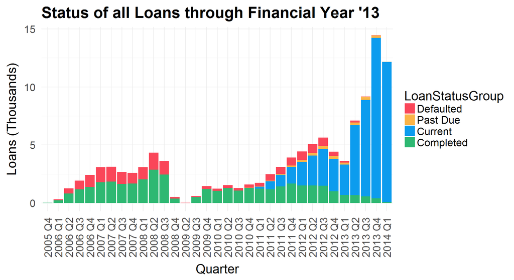

### Description Two

I have chosen this plot because of it’s combination of detail and simplicity. It makes for an easy way to evaluate the performance of Prosper laons.First let’s look at pre-2009. They were still a young company at the time, and we can see that with the sub-5000 loans per quarter figure. More importantly, though, all the loans originated at the time are either completed or defaulted (i.e. none are still ongoing). Now I can compare the relative sizes of the red and green bars, and I can easily tell that approximately half, or a bit less that half the loans that were granted, defaulted.

That’s not good, especially when they have to convince investors that they’re making solid investments. Now let’s look at post-2009. Right when they restarted servicing loans, for about the next year, we can see that the size of the red bar is much smaller relative to the green bar. That tells me that their minimum credit policy seems like it’s working - defaults look pretty low in number.

I chose to look at only the next year because there seem to be no, or an insignificant amount of loans still currently active. After that - 2011 onwards - we see the number of loans being originated rise tremendously. The red bar to green bar ratio seems to be increasing slowly, but it’s difficult to tell with the growing ‘Current’ blue bar in between. But a few questions arise - how many of those current loans will end up in the green, completed group in the future? How many will instead dive into the yellow of ‘Past Due’? And out of those, how many will make it out and enter green, and how many will fall into the dreadful red of ‘Defaulted’?

It’s difficult to say whether their new policies have improved investment quality - the first year certainly suggests so, but scaling up quickly invariably leads to some new problems. Only time can tell what color the blues in the plot will convert to.

### Plot Three

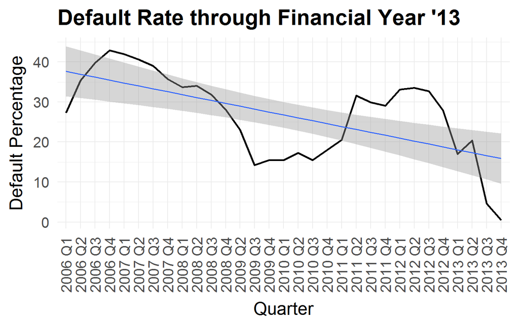

# Reflection

Starting as a beginner in data analysis, i feel that my experience is very less to deal with datasets having large number of variables like this one. I started this project thinking that i would easily get through it with utter ease, but it was not so. Skimming through the large set of features and collecting the ones which are really important to my analysis was the starting point. Then i used plots of various kinds like histogram, bar-chart, line graph, scatterplot etc. Initially when i took each variable to analyse, many of them didn’t show a clear picture of any useful trend. Then when i took pairs of variables to analyse, i started seeing plots showing relationships between the variables. This made me gain more interest in pursuing this project.

Later i thought of plotting 3 variables together and then took my exploration further and gained some insights from them.The main problem I ran into this dataset was overplotting. A lot of the time, I would hypothesize a relationship and then plot the data to check if it was true or not, but most of the time the sheer amount of data (and it’s variation) would disguise any trend that may exist. A solution would be to sample the data, but I chose not to do that this time (and opted instead for colouring it).

I’ve just mentioned a few questions that can be answered through this exploration but i feel there are still many other questions, and I’m sure there are answers to questions I haven’t even thought of. There are a number of different ways to take this project further. Firstly, I’ve focused on a small subset of the variables available in the dataset, and there is a vast amount of data I’ve chosen not to explore. I think I’d like to explore the investors side a bit more; look at investor profit and losses and their general activity in the peer-to-peer lending industry. Also, I would like to learn about the kind of plots and graphs specifically used by the finance industry, so that I can incorporate that knowledge into any future datasets I may explore. Lastly, although I haven’t learned it yet, I’d like to incorporate a machine learning algorithm into my exploration to predict the number of ongoing loans that will end up being defaulted. I believe that an accurate model will be very beneficial to Prosper, so it’s definitely something I’d like to look into, in the near future.